# BCB420 Assignment 1 Sabbir Hossain

##Background information here, paraphased from the paper. This was a really interesting paper, but I will save that discussion for the later part of this assignment. A prior transcriptome meta-analysis found significantly decreased levels of corticotropin-releasing hormone (CRH) mRNA in corticolimbic brain areas in MDD patients, indicating that cortical CRH-expressing (CRH+) cells are impaired in MDD. Although rodent studies reveal that cortical CRH is predominantly expressed in GABAergic interneurons, little is known about the characteristics of CRH+ cells in the human cerebral cortex and their relationship to MDD. Human volunteers without brain illnesses had their subgenual anterior cingulate cortex (sgACC) identified for CRH and markers of excitatory (SLC17A7), inhibitory (GAD1), and other interneuron subpopulations using fluorescent in situ hybridization (FISH) (PVALB, SST, VIP). Changes in CRH+ cell density and cellular CRH expression (n = 6/group) were investigated in MDD patients. RNA-sequencing was done on sgACC CRH+ interneurons from comparison and MDD participants (n = 6/group) to see if there were any variations between the two groups. In mice with TrkB function suppressed, the effect of decreased BDNF on CRH expression was investigated. GABAergic cells made up 80 percent of CRH+ cells, whereas glutamatergic cells made up 17.5 percent. VIP (52%) and SST (7%), as well as PVALB, were co-expressed by CRH+ GABAergic interneurons (7 percent ). MDD patients had lower CRH mRNA levels in GABAergic interneurons than control participants, despite no differences in cell density. The transcriptome profile of CRH+ interneurons suggests decreased excitability and less GABA release and reuptake. Further research revealed that these molecular alterations are not caused by altered glucocorticoid feedback, but rather occur downstream of a common neurotrophic function modulator.

Here is a direct link to the query for this dataset. (GSE193417).

# 1. Inquire and then download the required files from GEO.

Check to see if any packages that have been run above are missing or not installed properly.

```r
suppressWarnings({if (!requireNamespace("BiocManager", quietly = TRUE))
    install.packages("BiocManager")
if (!requireNamespace("GEOmetadb", quietly = TRUE))
    BiocManager::install("GEOmetadb")
if (!requireNamespace("limma", quietly = TRUE))
    BiocManager::install("limma")
if (!requireNamespace("org.Hs.eg.db", quietly = TRUE))
    BiocManager::install("org.Hs.eg.db")
if (!requireNamespace("edgeR", quietly = TRUE))
    BiocManager::install("edgeR")
if (!requireNamespace("tidyverse", quietly = TRUE))
    install.packages("tidyverse")
if (!requireNamespace("ggplot2", quietly = TRUE))
    install.packages("ggplot2")
if (!requireNamespace("org.Hs.eg.db", quietly = TRUE))
    BiocManager::install("org.Hs.eg.db")
if (!requireNamespace("AnnotationDbi", quietly = TRUE))
    BiocManager::install("AnnotationDbi")
if (!requireNamespace("readxl", quietly = TRUE))
    BiocManager::install("readxl")
if (!requireNamespace("RColorBrewer", quietly = TRUE))
    install.packages("RColorBrewer")
if (!requireNamespace("dplyr", quietly = TRUE))
    install.packages("dplyr")})
```

Load in the respective libraries for this assignment.

```r
library(Biobase)
library(BiocManager)
library(GEOmetadb)
library(edgeR)
library(biomaRt)
library(magrittr)
library(GEOquery)
library(RSQLite)
library(limma)
library(org.Hs.eg.db)
library(umap)
```

Download the GEO metadata, or load it from the disk if it is already has been downloaded before. Local copy is fine as well.

```r
if (!file.exists("GSE193417.rds")) {
  GSE193417 <- getGEO("GSE193417", GSEMatrix =TRUE, getGPL= FALSE)
  if (length(GSE193417) > 1) idx <- grep("GPL16791", attr(GSE193417, "names")) else idx <- 1
  GSE193417s <- GSE193417[[idx]]
  saveRDS(GSE193417, "GSE193417.rds")
} else {
  GSE193417 <- readRDS("GSE193417.rds")
}
```

Check to see if we have the dataset. If you do get an error you will need to delete all the files that were downloaded so far, and try again. Packages do not need to be removed.

```r
# Checkpoint ...
if (! exists("GSE193417")) {
  stop("PANIC: GSE193417 was not loaded. Or properly formatted.
       Clear everything and run code again from the start. Can't continue.")
}
```

Check to see that there are the correct number of samples in this series. There should be 12 samples in this series at the time of writing this comment. You can double check by running the next code block and looking for the number of series.

```r
length(Biobase::sampleNames(GSE193417))
```

```
## [1] 12
```

```r
Biobase::sampleNames(GSE193417) #GEO sequence names of all the samples used in this experiment.
```

```
##  [1] "GSM5799928" "GSM5799929" "GSM5799930" "GSM5799931" "GSM5799932"
##  [6] "GSM5799933" "GSM5799934" "GSM5799935" "GSM5799936" "GSM5799937"
## [11] "GSM5799938" "GSM5799939"
```

Slight Testing of the values. Making sure that everything is indeed okay.

```r
GSE193417
```

```
## $GSE193417_series_matrix.txt.gz
## ExpressionSet (storageMode: lockedEnvironment)
## assayData: 0 features, 12 samples
##   element names: exprs
## protocolData: none
## phenoData
##   sampleNames: GSM5799928 GSM5799929 ... GSM5799939 (12 total)
##   varLabels: title geo_accession ... tissue:ch1 (65 total)
##   varMetadata: labelDescription
## featureData: none
## experimentData: use 'experimentData(object)'
## Annotation: GPL15520
```

Download the supplementary files if there are any into the current working directory.

```r
if (!dir.exists('GSE193417')){
  gsefiles = getGEOSuppFiles('GSE193417')
  (fnames <- rownames(gsefiles))
} else {
  gsefiles = getGEOSuppFiles('GSE193417', fetch_files = FALSE)
  (fnames <- paste(getwd(), 'GSE193417', gsefiles$fname, sep = "/"))
}
```

```
## [1] "/home/rstudio/Assignment1/GSE193417/GSE193417_Raw_count_matrix_CRH.csv.gz"
## [2] "/home/rstudio/Assignment1/GSE193417/GSE193417_Sample_metadata.csv.gz"
```

```r
#Will give you the names of all the files that were downloaded using the getGEOSuppFiles.
#This is to just show the raw table that was acquired from getGEOSuppFiles.
```

# 2. Assess, Explore and Clean Sample File(s) and their metadata, then Map to HUGO symbols

```r
#Obtain platform and experiment data
gse <- getGEO("GSE193417", GSEMatrix = FALSE)
```

[output not shown]

[output not shown]

[output not shown]

[output not shown]

[output not shown]

[output not shown]

[output not shown]

[output not shown]

[output not shown]

[output not shown]

[output not shown]

[output not shown]

[output not shown]

[output not shown]

[output not shown]

[output not shown]

```r
gse_metadt <- Meta(gse)
gpl_metadt <- Meta(getGEO(names(GPLList(gse)[1])))
```

### Platform information - GPL15520 Illumina MiSeq (Homo sapiens)

**Platform Title**: Cell-Specific Transcriptomic Analysis of CRH+ cells Identifies Unique Cellular Responses to Chronic Stress

**Submission data**: Jan 10 2022

**Last update data**: Feb 22 2022

**Summary**: Rationale: A previous transcriptome meta-analysis revealed significantly lower levels of corticotropin-releasing hormone (CRH) mRNA in corticolimbic brain regions in major depressive disorder (MDD) subjects. Rodent studies show that cortical CRH is mostly expressed in GABAergic neurons; however, the characteristic features of CRH+ cells in human brain cortex and their association with MDD are largely unknown., Methods: Subgenual anterior cingulate cortex (sgACC) of human subjects without brain disorders were labeled using fluorescent in situ hybridization (FISH) for CRH and markers of excitatory (SLC17A7), inhibitory (GAD1) neurons, as well as markers of other interneuron subpopulations (PVALB, SST, VIP). MDD-associated changes in CRH+ cell density and cellular CRH expression (n=6/group) were analyzed. RNA-sequencing was performed on sgACC CRH+ neurons from comparison and MDD subjects (n=6/group), and analyzed for group differences., Results: About 80% of CRH+ cells were GABAergic and 17.5% were glutamatergic. CRH+ GABAergic neurons co-expressed VIP (52%), SST (7%), or PVALB (7%). MDD subjects displayed lower CRH mRNA levels in GABAergic neurons relative to comparison subjects without changes in cell density. CRH+ neurons show transcriptomic profile suggesting lower excitability and less GABA release and reuptake. Further analyses suggested that these molecular changes are not mediated by altered glucocorticoid feedback and potentially occur downstream for a common modulator of neurotrophic function., Summary: CRH+ cells in human sgACC are a heterogeneous population of GABAergic neurons, although largely co-expressing VIP. MDD is associated with reduced markers of inhibitory function of CRH+ neurons.

**Number of GEO datasets that use this technology**: 0

**Number of GEO samples that use this technology**: 12

Here is some housekeeping to make sure the information we have downloaded so far is correct and can be processed.

```r
mddInMe = read.csv(fnames[1],header=TRUE, check.names = FALSE)
colnames(mddInMe)[1] <- "EntrezID" #Will make adding Ensemble IDs really easy later on.
head(mddInMe, 5) #Displays the head
```

|  | EntrezID | CRH-Hu1001.bam | CRH-Hu1031.bam | CRH-Hu1047.bam | CRH-Hu1086.bam | CRH-Hu513.bam | CRH-Hu600.bam | CRH-Hu615.bam | CRH-Hu789.bam | CRH-Hu809.bam | CRH-Hu852.bam | CRH-Hu863.bam | CRH-Hu943.bam |
| --- | --- | --- | --- | --- | --- | --- | --- | --- | --- | --- | --- | --- | --- |
| 1 | ENSG00000000003 | 0 | 111 | 8 | 0 | 128 | 142 | 0 | 66 | 75 | 0 | 59 | 0 |
| 2 | ENSG00000000005 | 0 | 0 | 0 | 0 | 42 | 0 | 89 | 0 | 69 | 0 | 0 | 0 |
| 3 | ENSG00000000419 | 139 | 151 | 0 | 1 | 43 | 0 | 219 | 0 | 66 | 71 | 449 | 156 |
| 4 | ENSG00000000457 | 0 | 489 | 194 | 353 | 378 | 68 | 692 | 202 | 1 | 13 | 342 | 225 |
| 5 | ENSG00000000460 | 0 | 33 | 51 | 30 | 156 | 2 | 190 | 293 | 174 | 201 | 0 | 215 |

```r
colnames(mddInMe)
```

```
##  [1] "EntrezID"       "CRH-Hu1001.bam" "CRH-Hu1031.bam" "CRH-Hu1047.bam"
##  [5] "CRH-Hu1086.bam" "CRH-Hu513.bam"  "CRH-Hu600.bam"  "CRH-Hu615.bam"
##  [9] "CRH-Hu789.bam"  "CRH-Hu809.bam"  "CRH-Hu852.bam"  "CRH-Hu863.bam"
## [13] "CRH-Hu943.bam"
```

```r
length(colnames(mddInMe))
```

```
## [1] 13
```

```r
dim(mddInMe) #Tells you how many rows and columns there are respectively.
```

```
## [1] 19961    13
```

```r
length(unique(mddInMe$EntrezID))#This tells me how many unique gene Ids exist in this dataset, in this case they are all unique.However we do not know if all the datasets are valid.
```

```
## [1] 19961
```

Checking to see that all the gene names for each of the rows are unique. This number should be the same as the number of rows in the dataset. Furthermore, even though at this point they MIGHT be unique, as in there could be typos, or any other underlying issues, we need to remove them and make sure the data set is workable and clean to use. Since we will also need to normalize it and account for any outliers in future exercises of this assignment The more invalid data we remove now the better it is for us Remove any null or NA values that would cause any problems with the dataset. Just as a precaution. It really isn’t necessary in our case because the values are all unique as we established earlier but its good to do, because again we don’t know the “state” of uniqueness. NA values, typos, incorrect formats are no good for us.

```r
na.omit(mddInMe)
```

[output not shown]

[output cut: 9990 more lines]

# 4. Clean as required

It is recommended to remove features with insufficient readings as we started learning in lecture 4, according to the ‘edgeR’ protocol. There always exists a group of at least one which satisfies the different sample sequences in this experiment.This will tell us how many EntrezIDs we can expect to map at most based on the sample size cut off we introduced with respect to the guidelines used by edgeR and in lecture.

```r
filtMddInMe = sum(rowSums(mddInMe > 1) >= 6)
```

This will tell us how many EntrezIDs we can expect to map at most based on the sample size cut off we introduced with respect to the guidelines used by edgeR and in lecture.

```r
filtMddInMe <- (mddInMe[rowSums(mddInMe > 1) >= 6, ])
```

```r
samples <- data.frame(lapply(colnames(mddInMe)[2:13], function(x) {
  splt = unlist(strsplit(x, split = "."))
  c(splt[1], unlist(strsplit(splt[2], split = "-"))[c(0,1)])
}))
colnames(samples) <- colnames(mddInMe)[2:13]
rownames(samples) <- c("happy", "sad")

samples <- data.frame(t(samples))
```

Assign all the genes in the table an HUGO symbol based on the Ensemble ID for the gene respectively. We will remove all the respective values for duplicate genes, genes with too few. Paraphasing from the paper; “Sequencing data was analyzed as previously described (34). In short, HiSat2 (35) and Genomic-Alignments were used to align 2 100 bp paired-end reads to the GRCh38 human reference genome (ftp.ensembl.org/pub/release-86/fasta/homo sapiens/dna/) (36). After matching genes to exons, noise was reduced by deleting low-expressing genes with fewer than ten reads and not found in more than two-thirds of the samples. 79.4% and 14.4% of total reads acquired per participant (115,354,986 on average) were aligned to genome and exon, respectively. This study looked at 15,472 genes in total.”

```r
if(!exists('ensembl')){
  ensembl <- useMart(biomart = "ensembl", dataset="hsapiens_gene_ensembl")
}
if(!exists('geneIDs')){
  geneIDs <- getBM(attributes = c('ensembl_gene_id', 'hgnc_symbol'),
                                 filters = 'ensembl_gene_id',
                                 values = mddInMe$EntrezID,
                                 mart = ensembl)
}
dim(geneIDs)
```

```
## [1] 19915     2
```

We see that there are a few genes missing that have not been mapped. Recall that when we first called dim(mddInMe) we had 19961;rows i.e gene names and 13;columns i.e sample names return as results. This suggests that only 46 genes are un-mapped.However we know that it not true as checking the sample counts of too few for a few genes demonstrated that there are still a number of values that need to be removed. Which we will fix now.

```r
# unmappedsegs genes
unmappedsegsNums = nrow(filtMddInMe) - nrow(geneIDs)
#The unmapped segments and portions will be removed.
unmappedsegs <- dplyr::anti_join(filtMddInMe[1], geneIDs[1], by = c("EntrezID" = "ensembl_gene_id"))
#Remove some repitions
FinalGeneFilter <- dplyr::inner_join(geneIDs, filtMddInMe, by = c("ensembl_gene_id" = "EntrezID"))
tempRepeats <- data.frame(table(geneIDs$ensembl_gene_id))
#And then again.
FinalGeneFilter <- FinalGeneFilter[!(FinalGeneFilter$hgnc_symbol=="STRA6LP" | FinalGeneFilter$hgnc_symbol=="LINC00856"),]
#And again. The aim is to remove any of the hgnc symbols that mapped to more than one Ensemble IDs. Essentially the Ensemble IDs should be treated as some sort of function. For every 1x, there is exactly 1y to pair with it. Lock and key so to speak.
FinalGeneFilter <- FinalGeneFilter[!(FinalGeneFilter$hgnc_symbol=="POLR2J3" | FinalGeneFilter$hgnc_symbol=="TBCE"),]
goodHGNCboy <- data.frame(table(geneIDs$hgnc_symbol))
FinalGeneFilter <- FinalGeneFilter[!(FinalGeneFilter$hgnc_symbol ==""), ]


keep = rowSums(FinalGeneFilter[2:13] >1) >= 6
FinalGeneFilter <- FinalGeneFilter[keep,]
dim(FinalGeneFilter)
```

```
## [1] 15349    14
```

Which is a lot less than what we had initially.

```r
#Check for more duplicates after sorting the first time.
smmryGeneCts <- sort(table(FinalGeneFilter$hgnc_symbol), decreasing = TRUE)
smmryGeneCts[which(smmryGeneCts > 1)]
```

```
## named integer(0)
```

```r
#Going through the first time, there were some repititions missing and we had to go back to remove them manually.
```

The finally percentage of removals due to duplications, NA values etc.

```r
mddnumbers = length(unique(mddInMe$EntrezID))
goodmddnumbers = length(unique(FinalGeneFilter$ensembl_gene_id))
percentageleft = goodmddnumbers/mddnumbers
percentageremoved <- (1 - percentageleft) * 100
cat(paste("The total amount of genes removed so far is:", percentageremoved))
```

```
## The total amount of genes removed so far is: 23.1050548569711
```

Convert to Matrix and then to Vector, this will be useful later when we are subsetting across various files and values of the data sctructure.

```r
# Create a matrix
matrixdata <- as.matrix(mddInMe)[, 2:13]

# Create a vector
vectordata <- as.vector(mddInMe)[, 2:13]

matrixdata2 <- as.matrix(FinalGeneFilter)[, 3:14]
vectordata2 <- as.vector(FinalGeneFilter)[, 3:14]
```

Edge Case calculation represented as a variable for the final normalized values.

```r
d <- edgeR::cpm(FinalGeneFilter[,3:14])
```

Manually doing this because I had a really frustrating time regarding the subsetting.

```r
samples <- data.frame(
  lapply(colnames(mddInMe), FUN=function(x){
    unlist(strsplit(x, split="\\_"))[c(2,3)]
  }
))
colnames(samples) <- ordered(colnames(mddInMe))
rownames(samples) <- c("sample_number", "group")

#Not going to lie this could have been done with a forloop or even subsetting. I wanted to challenged myself and understand the different aspects of subsetting and value accession.
#It was quite probably the worst thing I have ever put myself through.
samples[2, 2:13] = 1
samples[1, 2] = 'CRH-Hu1001 - 2'
samples[1, 3] = 'CRH-Hu1031 - 1'
samples[1, 4] = 'CRH-Hu1047 - 1'
samples[1, 5] = 'CRH-Hu1086 - 1'
samples[1, 6] = 'CRH-Hu513 - 2'
samples[1, 7] = 'CRH-Hu600 - 2'
samples[1, 8] = 'CRH-Hu615 - 1'
samples[1, 9] = 'CRH-Hu789 - 1'
samples[1, 10] = 'CRH-Hu809 - 2'
samples[1, 11] = 'CRH-Hu852 - 1'
samples[1, 12] = 'CRH-Hu863 - 2'
samples[1, 13] = 'CRH-Hu943 - 2'
samples[2, 2] = 2
samples[2, 13] = 2
samples[2, 12] = 2
samples[2, 10] = 2
samples[2, 6:7] = 2
```

##MDS plot

[figure not shown]

```r
plotMDS(d,
        labels=samples$sample_number,
        col = rainbow(length(levels(factor(samples[1,]))), alpha=1)[factor(samples[1,])], main="MDS plot of Norm. Retinal RNASeq Samples")
```

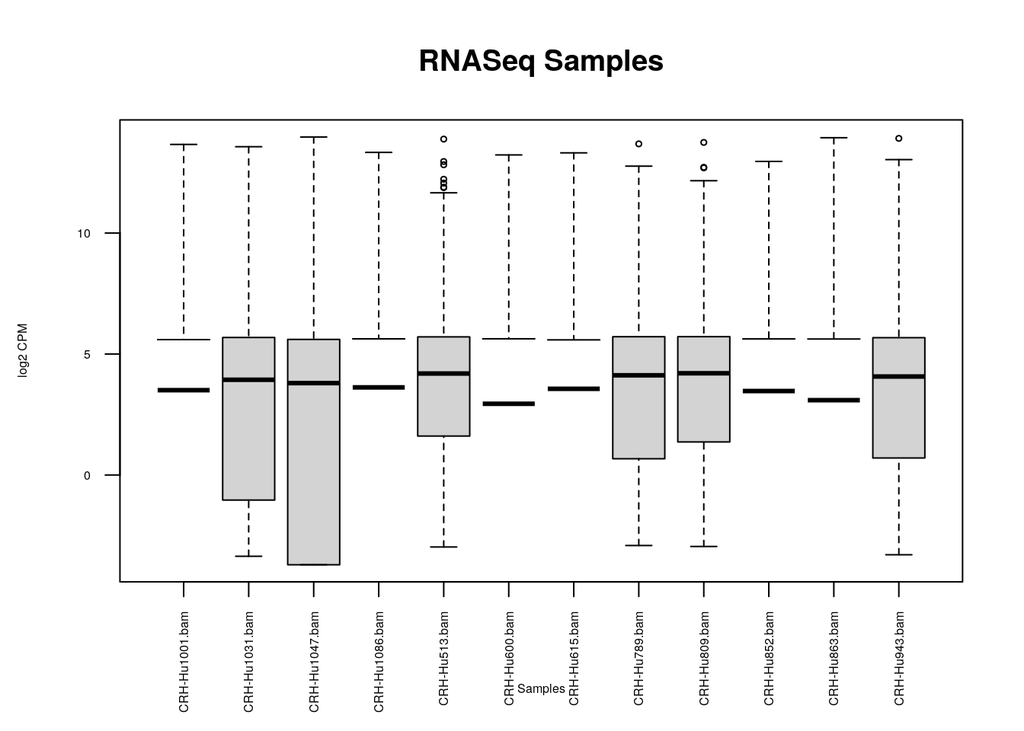

```r
data2plot <- log2(edgeR::cpm(mddInMe[,2:13]))
boxplot(data2plot, xlab = "Samples", ylab = "log2 CPM", las = 2, cex = 0.5, cex.lab = 0.5, cex.axis = 0.5, main = "RNASeq Samples")
```

##Box plot for normalized values

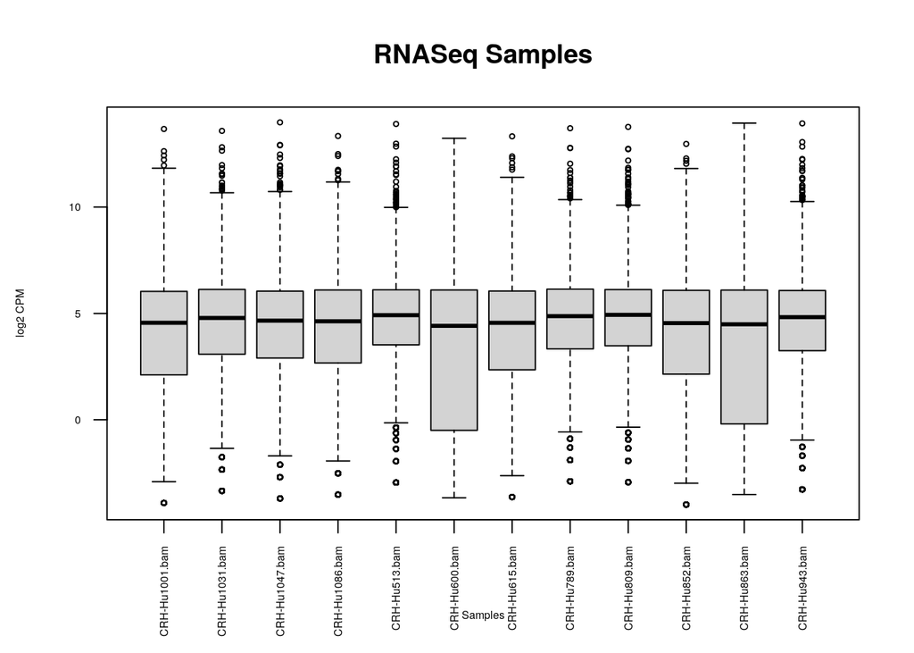

```r
data2plot <- log2(edgeR::cpm(FinalGeneFilter[,3:14]))
boxplot(data2plot, xlab = "Samples", ylab = "log2 CPM", las = 2, cex = 0.5, cex.lab = 0.5, cex.axis = 0.5, main = "RNASeq Samples")
```

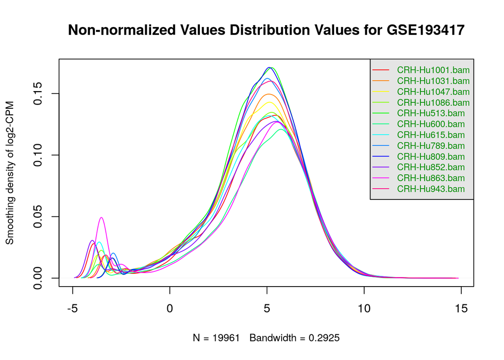

```r
ctsDenct <- apply(log2(edgeR::cpm(mddInMe[,2:13])), 2, density)

xlim <- 0; ylim <- 0
for (i in 1:length(ctsDenct)) {
  xlim <- range(c(xlim, ctsDenct[[i]]$x));
  ylim <- range(c(ylim, ctsDenct[[i]]$y))
}
cols <- rainbow(length(ctsDenct))
ltys <- rep(1, length(ctsDenct))

plot(ctsDenct[[1]], xlim = xlim, ylim = ylim, type = "n", ylab = "Smoothing density of log2-CPM", main = "Non-normalized Values Distribution Values for GSE193417", cex.lab = 0.85)
for (i in 1:length(ctsDenct))
  lines(ctsDenct[[i]], col = cols[i], lty = ltys[i])

legend("topright", colnames(data2plot), col=cols, lty=ltys, cex=0.75, border="blue", text.col = "green4", merge = TRUE, bg = "gray90")
```

##Density Curve for Normalized Distribution Values

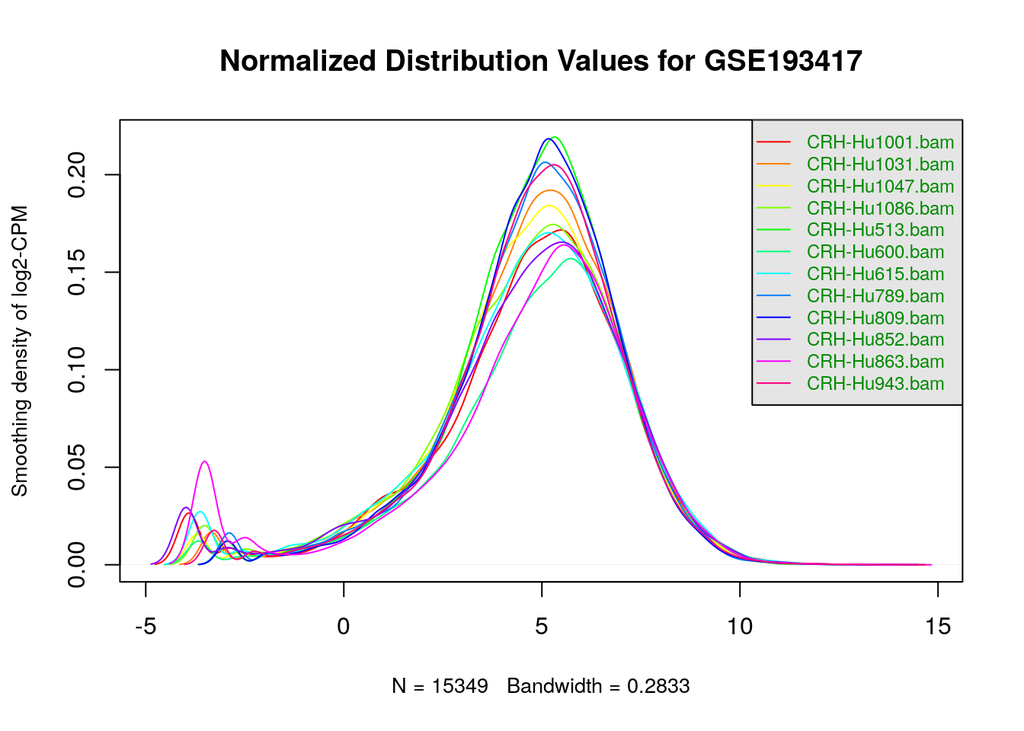

```r
ctsDenct <- apply(log2(edgeR::cpm(FinalGeneFilter[,3:14])), 2, density)

xlim <- 0; ylim <- 0
for (i in 1:length(ctsDenct)) {
  xlim <- range(c(xlim, ctsDenct[[i]]$x));
  ylim <- range(c(ylim, ctsDenct[[i]]$y))
}
cols <- rainbow(length(ctsDenct))
ltys <- rep(1, length(ctsDenct))

plot(ctsDenct[[1]], xlim = xlim, ylim = ylim, type = "n", ylab = "Smoothing density of log2-CPM", main = "Normalized Distribution Values for GSE193417", cex.lab = 0.85)
for (i in 1:length(ctsDenct))
  lines(ctsDenct[[i]], col = cols[i], lty = ltys[i])

legend("topright", colnames(data2plot), col=cols, lty=ltys, cex=0.75, border="blue", text.col = "green4", merge = TRUE, bg = "gray90")
```

Simple log ration expression of a sample within the data set mapped against other sample within the data set. I did this for both normalized and non normalized values. The distribution of the samples is really well put together. It looks really pretty, and I am amazed that it looks this good. I am not sure why this is the case for these two, I understand that I compared the same two before and after normalization so that is why in terms of looks they appear identical because as we have already concluded that these are really great for getting the overall vibe for a set amount of data and being able to predict it based on the desnity/adjustments etc. because of normalization and distribution. Though I am wondering why they look like a kite, I have seen some really pretty graphs before, but I think this is the best one yet. Possibly due to the fact that I made it. ##Expression Log Ratios

[figure not shown]

```r
limma::plotMA(log2(mddInMe[,c(2,13)]), main = "CRH-Hu1086-1 v.s. CRH-Hu1001")
```

[figure not shown]

```r
limma::plotMA(log2(FinalGeneFilter[,c(3,14)]), main = "CRH-Hu1086-1 v.s. CRH-Hu1001")
```

# 6. Interpretation

**Why is the dataset of interest to you?**’ As someone who struggle with mental health issues, I am always interested in these topics. It can only make us more aware and better for the long term once we are able to understand how to take care of our mind, and not just our physical bodies too. Broken bones almost always heal, but broken souls do not. Or so I’ve heard.

**Were there expression values that were not unique for specific genes? How did you handle these?** I removed any genes that were not unique, or non-availbe. I don’t think I had any that were duplicated in terms of expression, but I had a lot of the same hgnc symbols.

**How many outliers were removed?** See above for the specific amount. 23% approximately.

**How did you handle replicates?** Removed them in the filtered dataset but kept them in my orignal data set that was loaded.

**What is the final coverage of your dataset?** Approximately 15349. Which is slightly lower than the paper’s but I suppose they did not remove any outlines.

##Final Dataset With everything removed and accounted for, normalized etc.

```r
FinalGeneFilter <- data.frame(FinalGeneFilter)
```

# 7. Citations

1. R programming for data science: https://bookdown.org/rdpeng/rprogdatascience/data-analysis-case-study-changes-in-fine-particle-air-pollution-in-the-u-s-.html
2. Lecture modules: https://q.utoronto.ca/courses/248455/modules
3. Oh, Hyunjung & Newton, Dwight & Lewis, David & Sibille, Etienne. (2022). Lower Levels of GABAergic Function Markers in Corticotropin-Releasing Hormone-Expressing Neurons in the sgACC of Human Subjects With Depression. Frontiers in Psychiatry. 13. 10.3389/fpsyt.2022.827972.

```r
citation("GEOmetadb")
```

```
##
## A BibTeX entry for LaTeX users is
##
##   @Article{,
##     author = {Yuelin Zhu and Sean Davis and Robert Stephens and Paul S. Meltzer and Yidong Chen},
##     title = {GEOmetadb: powerful alternative search engine for the Gene Expression Omnibus.},
##     journal = {Bioinformatics (Oxford, England)},
##     year = {2008},
##     month = {Dec},
##     day = {01},
##     volume = {24},
##     number = {23},
##     pages = {2798--2800},
##     abstract = {The NCBI Gene Expression Omnibus (GEO) represents the largest public repository of microarray data. However, finding data in GEO can be challenging. We have developed GEOmetadb in an attempt to make querying the GEO metadata both easier and more powerful. All GEO metadata records …
##     issn = {1367-4811},
##     doi = {10.1093/bioinformatics/btn520},
##     url = {http://www.ncbi.nlm.nih.gov/pubmed/18842599},
##     language = {eng},
##   }
```

```r
citation("GEOquery")
```

```
##
## A BibTeX entry for LaTeX users is
##
##   @Article{,
##     author = {Sean Davis and Paul Meltzer},
##     title = {GEOquery: a bridge between the Gene Expression Omnibus (GEO) and BioConductor},
##     journal = {Bioinformatics},
##     year = {2007},
##     volume = {14},
##     pages = {1846--1847},
##   }
```

```r
citation("biomaRt")
```

```
##
##
##   Mapping identifiers for the integration of genomic datasets with the
##   R/Bioconductor package biomaRt. Steffen Durinck, Paul T. Spellman,
##   Ewan Birney and Wolfgang Huber, Nature Protocols 4, 1184-1191 (2009).
##
##   BioMart and Bioconductor: a powerful link between biological
##   databases and microarray data analysis. Steffen Durinck, Yves Moreau,
##   Arek Kasprzyk, Sean Davis, Bart De Moor, Alvis Brazma and Wolfgang
##   Huber, Bioinformatics 21, 3439-3440 (2005).
##
## To see these entries in BibTeX format, use 'print(<citation>,
## bibtex=TRUE)', 'toBibtex(.)', or set
## 'options(citation.bibtex.max=999)'.
```

```r
citation("edgeR")
```

```
##
## See Section 1.2 in the User's Guide for more detail about how to cite
## the different edgeR pipelines.
##
##   Robinson MD, McCarthy DJ and Smyth GK (2010). edgeR: a Bioconductor
##   package for differential expression analysis of digital gene
##   expression data. Bioinformatics 26, 139-140
##
##   McCarthy DJ, Chen Y and Smyth GK (2012). Differential expression
##   analysis of multifactor RNA-Seq experiments with respect to
##   biological variation. Nucleic Acids Research 40, 4288-4297
##
##   Chen Y, Lun ATL, Smyth GK (2016). From reads to genes to pathways:
##   differential expression analysis of RNA-Seq experiments using
##   Rsubread and the edgeR quasi-likelihood pipeline. F1000Research 5,
##   1438
##
## To see these entries in BibTeX format, use 'print(<citation>,
## bibtex=TRUE)', 'toBibtex(.)', or set
## 'options(citation.bibtex.max=999)'.
```